# Rifampin PBPK Model

Nino Koci

2024-12-20

## Introduction

For this project, I focused on developing a pharmacokinetic model for *Rifampin*, a common antibiotic used to treat tuberculosis. Since *Rifampin* is usually taken orally and works in the lungs where the tuberculosis bacterium primarily resides, the pharmacokinetic model would have to account for the drug circulating in the blood and reaching various tissues in the body before reaching its site of action. Therefore, a physiologically based pharmacokinetic(PBPK) model would be the best approach to the issue of vasculature, as it considers the different drug distributions in other tissues of the body. I have chosen to implement the model from Lyons et al.(2013), a PBPK model of *Rifampin* in mice. In this project, I aim to implement the model from Lyons et al., by exploring additional metrics not addressed in the original article. In addition, I will change the model’s dosing to an intravenous(IV) dose method to better understand the differences between oral and injected doses.

## Methods

### Core Model Implementation

I intend to fully implement the methodology outlined in Lyons et al., with a few changes to better suit the model implementation. I will not perform a Monte Carlo simulation of the parameter values, as the methodology is not well-defined. Instead, I will estimate the median change in *Rifampin* concentrations over time using the median parameter values from **Table 1** and **Table 2** of the article. This change will allow me to develop all figures in the article except *Figure 11*(*Figure 7.A* in the article) and the percentile-based values in *Figures 3-6*.

#### ODEdesign

To implement the model from Lyons et al., I used a MATLAB app, SimBiology, designed for PK/PD modeling. In the first phase of the model, I used graphical design to draw and implement the model diagram, adding additional elements that allow SimBiology to recognize the drug in each compartment and record reactions between compartments; these functions are automatically incorporated into the SimBiology code and returned as ODEs. The ODEs will therefore be implemented via a diagram based on Figure 1 and the ODEs in the appendix of Lyons et al. We can see in the diagram that each node, box, and line is specifically designed and programmed to represent the kinetics occurring within each compartment.

> Comparison between SimBiologyPBPK model and Lyons et al. organism diagrams:

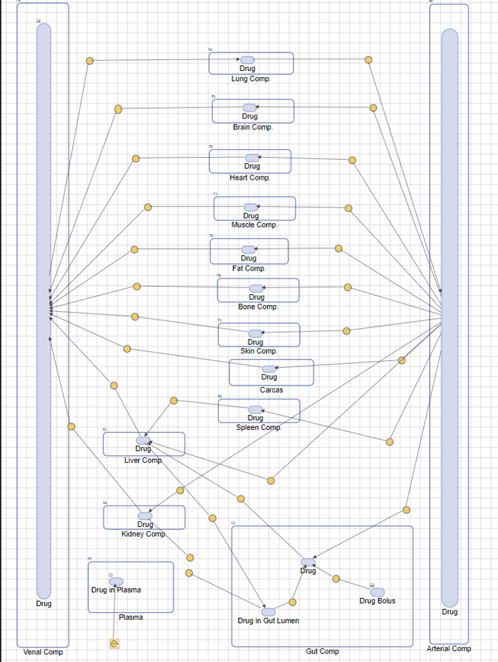

- FIGURE 1.A - SimBiologyPBPK model dynamic diagram.

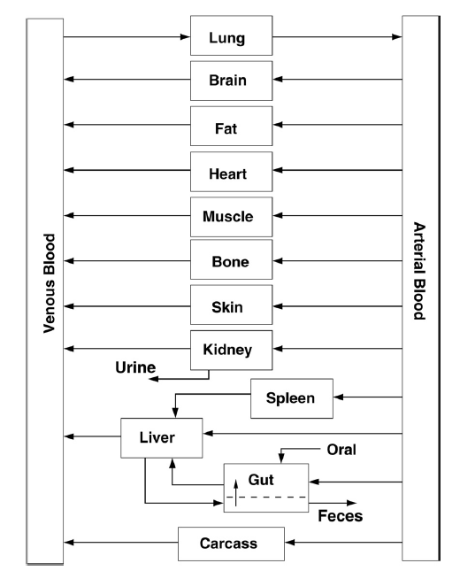

- FIGURE 1.B - Lyons et al. PBPK diagram.

#### Parameter Estimation

Most of the parameters will come directly from the paper without changes.

Tissue volume and blood flow must be calculated using their fractional values and body weight in kilogram(*kg*). All the calculations are in the **Excel** sheet attached to the final submission. Blood/plasma partition is not explicitly stated in the article; however, based on the follow-up paper by Lyons et al. (2015), its value is *0.9*.

Compartments will remain the same in this model. Although initially in *kg*, the volume will be set to liters(*L*) since we assume the tissue’s *1kg/L* density.

The dose will be represented in mg, the multiple of the drug dose, and the body weight in kilograms. To help generate Figures 2-7B from the article, the drug will have these dose variants: - *10mg/kg* for plasma, liver, kidney, and lung - *15mg/kg* for plasma only - *20mg/kg* for plasma only - *40mg/kg* for a single bolus dose for plasma only - *10mg/kg* for three doses every 24 hours for plasma only

For all doses, the start time will be 0 hours.

#### Drug Administration and pharmacokinetics.

Species are compartment elements, and the *Rifampin* concentration will be the only element we will observe in a 120-hour timeframe. All initial concentrations of *Rifampin* in each compartment will be set to zero. *Figures 3-7* show that the drug plasma concentration can be derived from the venous drug concentration using the blood-to-plasma partition coefficient. However, we will also examine drug concentrations in the lung, liver, and kidney compartments to reproduce *Figure 4* from Lyons et al. Given that our dose is in mg and our volume is in *L*, the model will use *mg/m* as the concentration unit. Lyons et al. report concentrations in tissues as *μg/g* and in plasma as *μg/mL*. However, given the *1kg/L* assumption, all these concentration units should be in a *1:1* ratio with each other.

Variations in the *50%* ± muscle/blood partition factor(*PM*) will be included and tested separately at a *10mg/kg* single oral dose to help recreate Figure 7.B.

For recreating Figure 2 and Table 3, we will use the non-compartmental analysis (*NCA*) and Observables features in the **SimBiology** model analyzer to calculate plasma *AUC*, *tmax*, *Cmax*, and *t1/2*.

#### Performing Pertubations

The second perturbation in this model will be looking at how this drug can be changed from oral to IV injectable. As such, we will keep the same 10mg/kg dose, both single and multiple, to see how the injectable dose has changed the dose-response in the plasma, liver, kidney, and lung. We will also investigate the AUC, Cmax, tmax, and t1/2 in plasma for the single dose. The other single doses will not be recorded since 10mg/kg is sufficient to see the change.

## Results and Discussion

### Model Validation

> **Table 1**: *Rifampin* mouse plasma concentration NCA results from a **10mg/kg** single oral dose from Lyons et al., the SimBiologyPBPK model, and the **10mg/kg** single IV *Rifampin* dose pertubation:

| NCA_Parameters | Lyons_et_al_Predicted | Lyons_et_al_Observed | Single_Oral | Single_dose_IV |
| --- | --- | --- | --- | --- |
| Cmax (μg/mL) | 11.41 | 10.58 ± 0.28 | 11.43 | 339.79 |
| tmax (h) | 1.78 | 1.33 ± 0.58 | 1.80 | 0 |
| half-life (t1/2) (h) | 6.77 | 7.61 ± 1.32 | 6.95 | 6.23 |
| AUC (μg·h/mL) | 132.90 | 139.7 ± 10.7 | 133.91 | 135.28 |

> **Figure 2**: Comparsion between the plasma AUC between the SimBioloy Output and Lyons et al.:

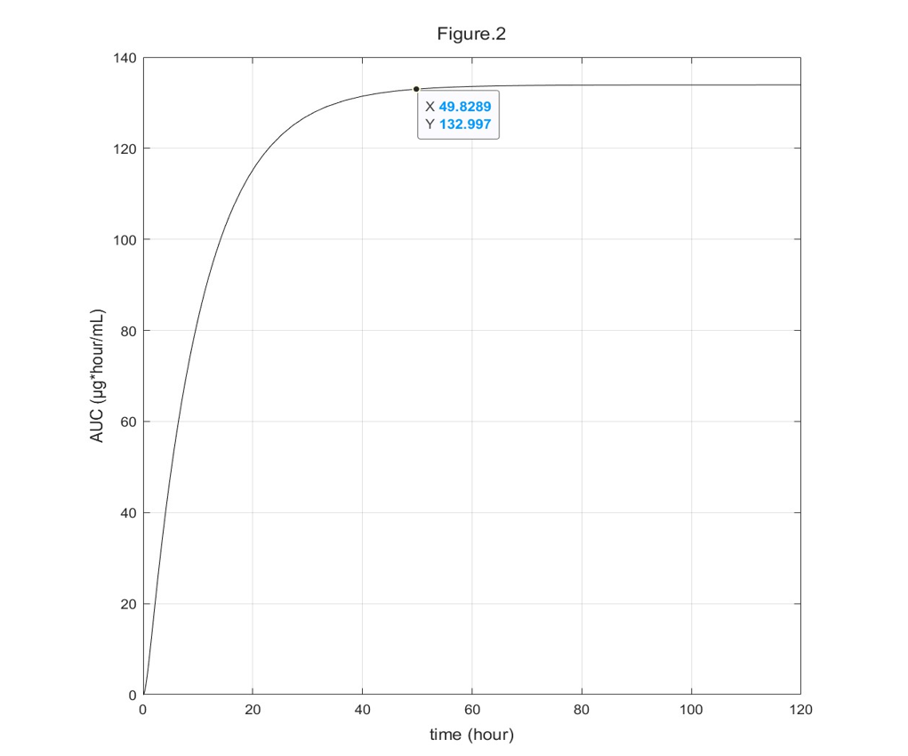

**FIGURE 2.A** - SimBiologyPBPK model plasma *AU*C for *10mg/kg* single oral dose.

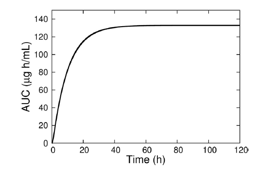

> **Figure 3**: Comparison of the *10mg/mL* and *15mg/kg* single oral bolus dose *Rifampin* concentrations over time in mouse plasma between Lyons et al. and the SimBiology PBPK model:

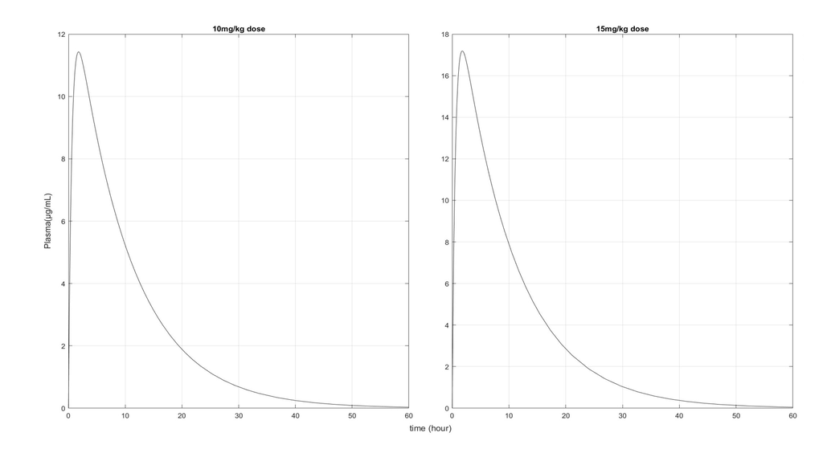

**FIGURE 3.A** - SimBiology PBPK model results for *10mg/m*L and 1*5mg/kg* single oral bolus dose Rifampin concentrations over time in mouse plasma.

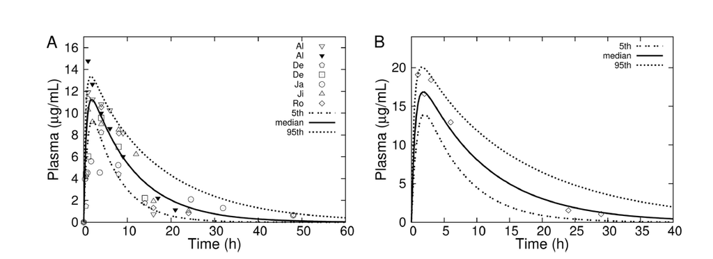

**FIGURE 3.B** - Lyons et al. results for *10mg/mL* and 15mg/kg single oral bolus dose Rifampin concentrations over time in mouse plasma.

> **Figure 4**: Comparison of the **10mg/mL** single oral dose *Rifampin* concentrations over time in mouse plasma, lung, liver, and kidney between Lyons et al.(2013) and the SimBiology PBPK model:

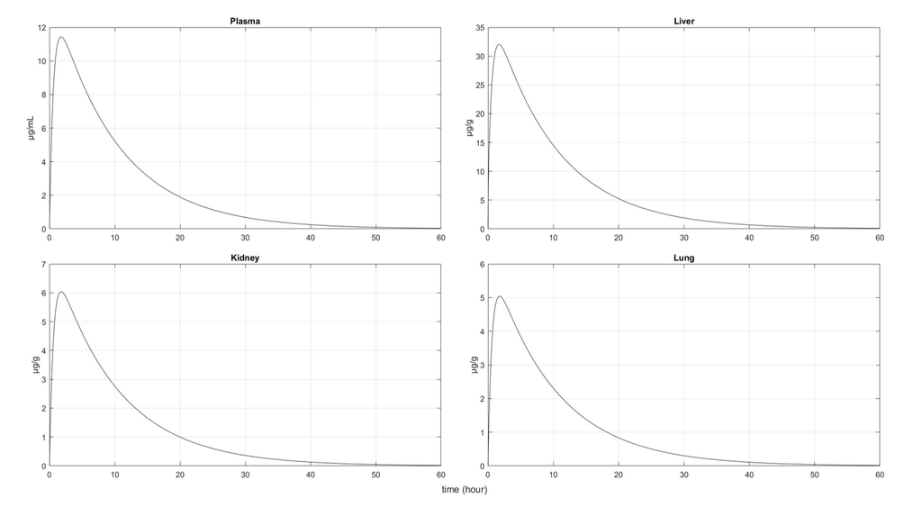

**FIGURE 4.A** - SimBiology PBPK model results for *10mg/mL* single oral bolus dose *Rifampin* concentrations over time in mouse plasma, lung, liver, and kidney.

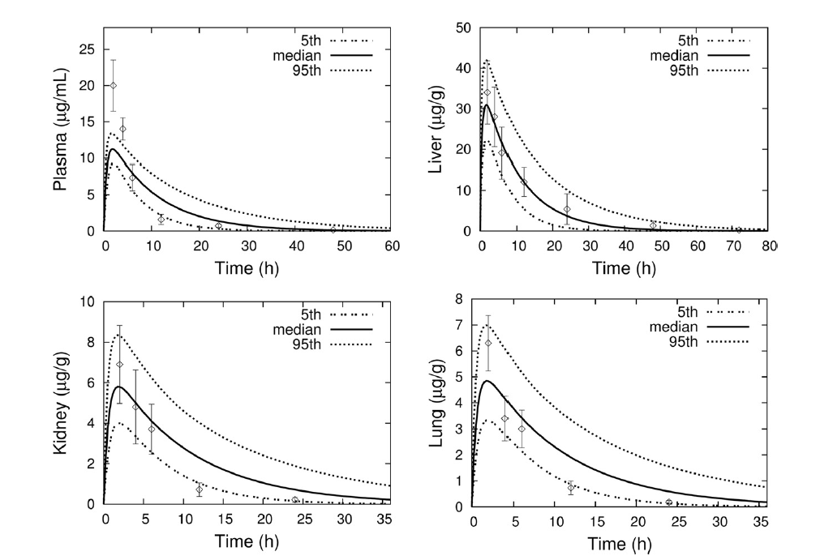

- **FIGURE 4.B** - Lyons et al. results for *10mg/mL*single oral bolus dose *Rifampin* concentrations over time in mouse plasma, lung, liver, and kidney.

> **Figure 5**: Comparison of the *10mg/mL* repeated multiple oral bolus dose *Rifampin* concentrations over three 24hr rounds in mouse plasma and liver:

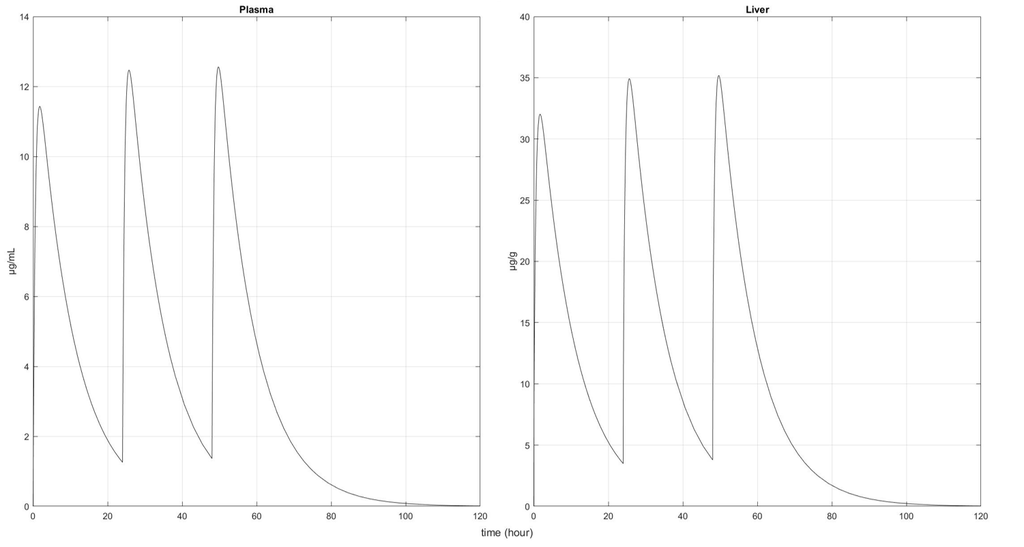

- **FIGURE 5.A** - SimBiology PBPK model resuts for *10mg/mL* repeated multiple oral bolus dose *Rifampin* concentrations over three 24hr rounds in mouse plasma and liver.

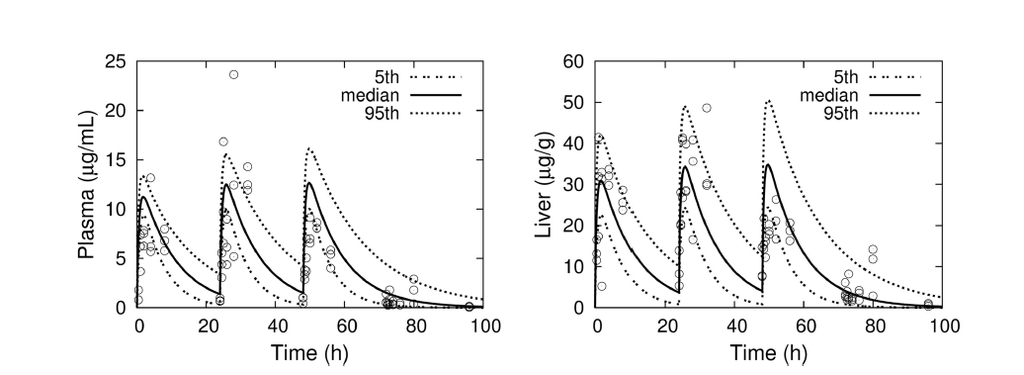

- **FIGURE 5.B** - Lyons et al.results for *10mg/mL* repeated multiple oral bolus dose *Rifampin* concentrations over three 24hr rounds in mouse plasma and liver.

> **Figure 6**: Comparison of the *10mg/mL*, *20mg/kg*, and *40mg/kg* oral bolus dose *Rifampin* concentrations over time in mouse plasma between SimBiology PBPK model and Lyons et al.

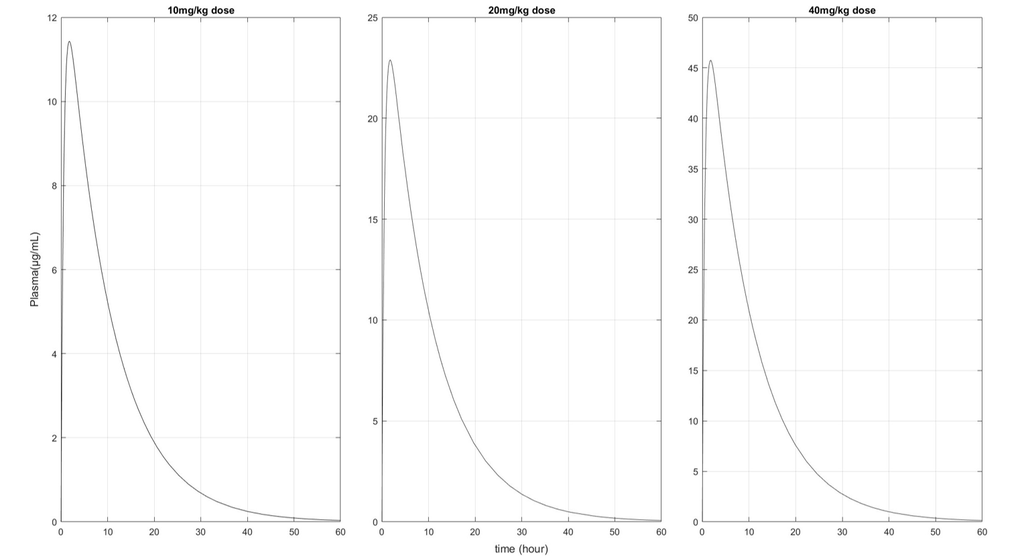

- **FIGURE 6.A** - SimBiology PBPK model PBPK model results for *10mg/mL*, *20mg/kg*, and *40mg/kg* single oral bolus dose of *Rifampin* concentrations over time in mouse plasma.

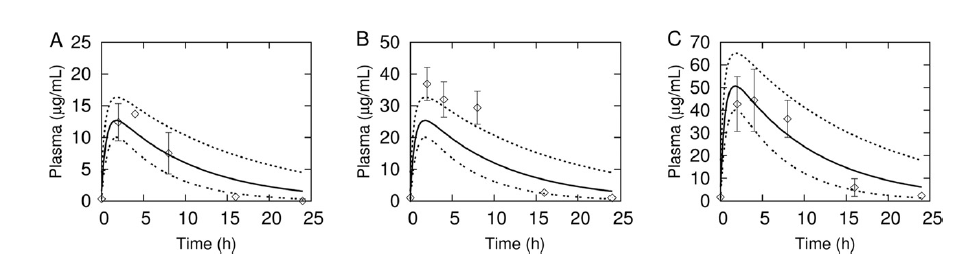

- FIGURE 6.B - Lyons et al.results for 10mg/mL, 20mg/kg, and 40mg/kg single oral bolus dose of *Rifampin* concentrations over time in mouse plasma.

> **Figure 7**: Comparison of the *10mg/mL* baseline plasma *Rifampin* concentration over time with a *50%* increase and decrease in **SimBiology** PBPK model and Lyons et al.

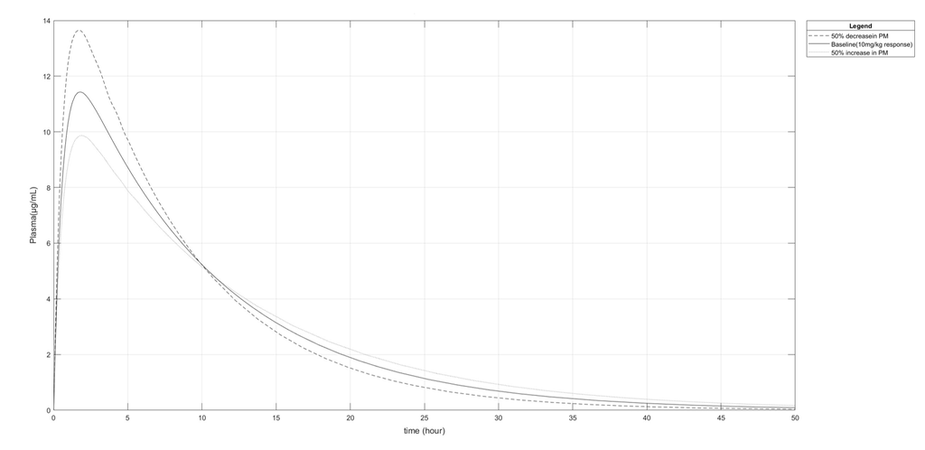

- **FIGURE 7.A** - SimBiology PBPK model results for 10mg/mL baseline plasma *Rifampin* concentration over time with a 50% increase and decrease of the muscle/blood partition factor(*PM*).

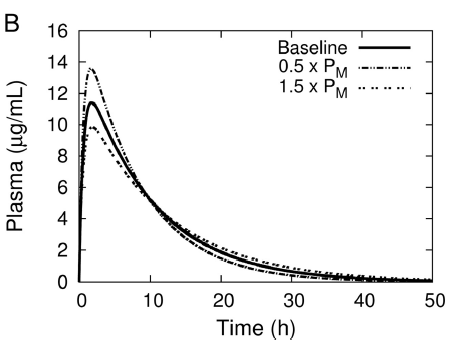

- **FIGURE 7.B** - Lyons et al.results for *10mg/mL* baseline plasma *Rifampin* concentration over time with a *50%* increase and decrease of the muscle/blood partition factor(*PM*).

Overall, the SimBiology model results indicate that it was successfully implemented with the median parameter values and yielded results similar to those of the non-compartmental analysis. Indicating that the recreation was relatively successful. However in hthe future we must attempt to recreate the *Monte Carlo* simulation in MATLAB.

### Perturbations

#### Exploring the sensitivity seen in Lyons et al.

By varying the three additional parameters(*ka*, *CL*, *Fa*), we can make a few observations:

By varying the *ka*, we see in *Figure 8* that a higher ka correlates with the reaction reaching the maximum concentration faster. This aligns with the logic that a higher absorption rate means the drug is absorbed into the plasma much more quickly.

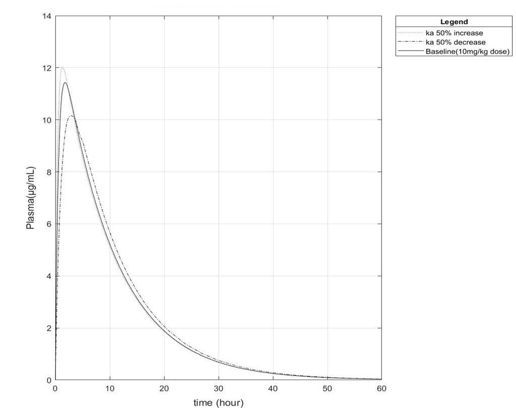

- **FIGURE 8** - 10mg/mL baseline plasma Rifampin concentration over time with a 50% increase and decrease in absorption rate(ka)

By varying the clearance rate (*CL*), we observe in *Figure 9* that the drug retained in the system increases as the *CL* decreases. This follows the logic that the lower the drug is eliminated from the system through the excretory system, the more of the drug remains in the system.

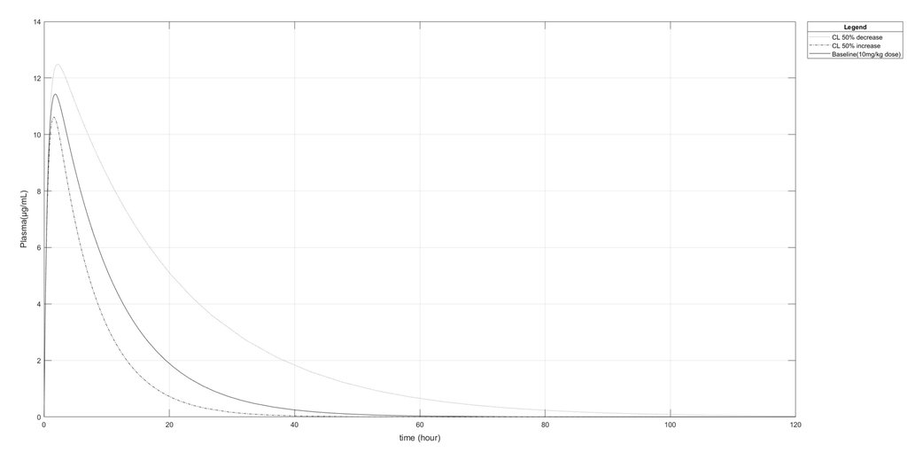

- **FIGURE 9** - 10mg/mL baseline plasma *Rifampin* concentration with a *50%* increase and decrease in clearance rate(*CL*).

In both cases, we see a lower *Fa* rate correlated to a lower maximum concentration of the drug in plasma. This follows the logic that we will get a smaller response by decreasing the amount of drug that enters the system.

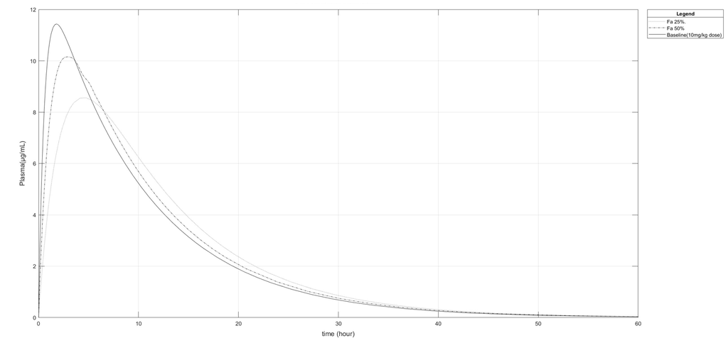

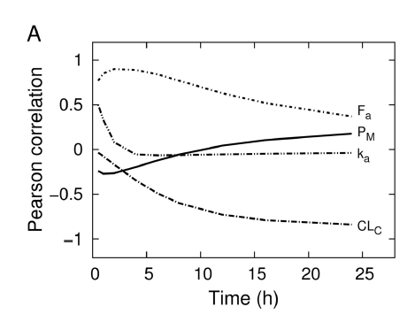

- **FIGURE 11** -Pearson correlation coefficients between sensitive parameters and *10mg/kg* single oral dose of *Rifampin* plasma concentration as a function of time.

#### Intra Venous(IV) *Rifampin* injection

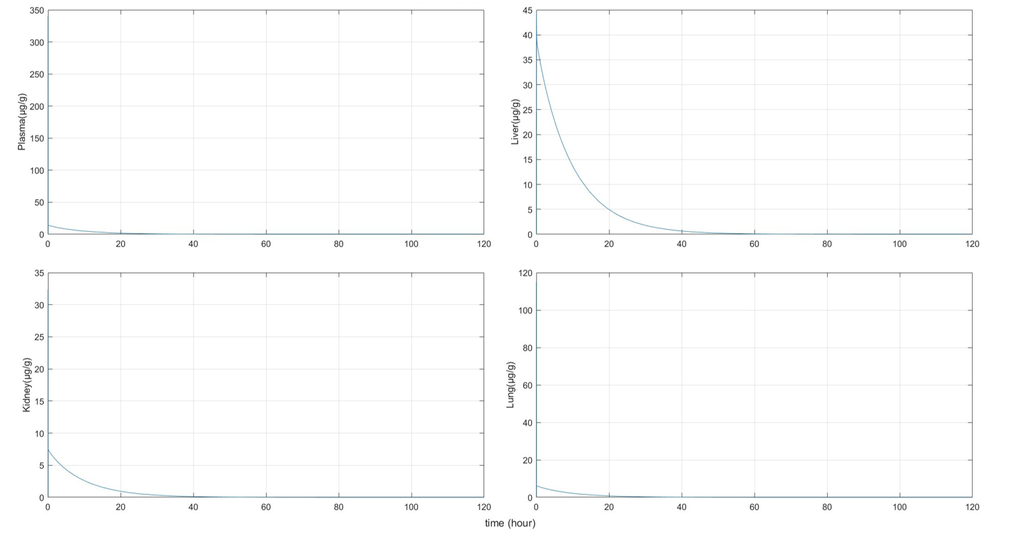

- **FIGURE 12** - *10mg/mL* IV bolus dose Rifampin concentrations in mouse plasma, lung, liver, and kidney.

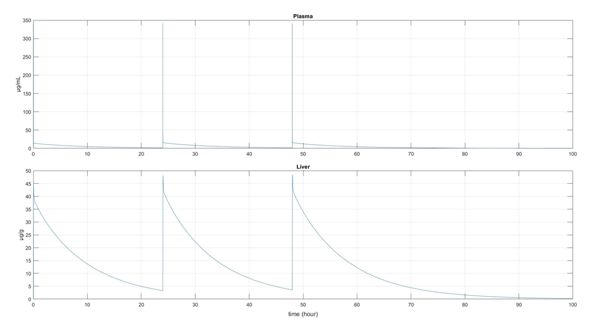

- **FIGURE 13** - *10mg/mL* repeated IV bolus dose Rifampin concentrations in mouse plasma and liver.

## References

1. Lyons, M. A., & Lenaerts, A. J. (2015). Computational pharmacokinetics/pharmacodynamics of rifampin in a mouse tuberculosis infection model. Journal of Pharmacokinetics and Pharmacodynamics, 42(4), 375–389. https://doi.org/10.1007/s10928-015-9419-z
2. Lyons, M. A., Reisfeld, B., Yang, R. S. H., & Lenaerts, A. J. (2013). A Physiologically Based Pharmacokinetic Model of Rifampin in Mice. Antimicrobial Agents and Chemotherapy, 57(4), 1763–1771. https://doi.org/10.1128/AAC.01567-12
3. https://www.mathworks.com/help/simbio/